# Simulations

2026-06-04

# Simulations

## Type I error

At $\alpha = 5\%$, Bradley’s liberal robustness criterion treats empirical rejection rates between $2.5\%$ and $7.5\%$ as acceptable [@Bradley:1978]. Abbreviations are: F = Fisher’s one-way ANOVA; W = Welch’s heteroscedastic ANOVA; L = Levene gate selecting F or W; KW = Kruskal–Wallis; SW = Shapiro–Wilk gate selecting W or KW; SW+L = Shapiro–Wilk gate selecting KW or, if the parametric branch is retained, Levene gate selecting F or W.

In the identical-distribution setting, both relevant null hypotheses are true: equal means for F, W, and L, and equal rank distributions for KW; SW and SW+L both remain within Bradley bounds in all conditions, showing that the automatic route does not inflate rejection when both candidate null hypotheses are true (Figure @ref(fig:route1-identical-typeI)).

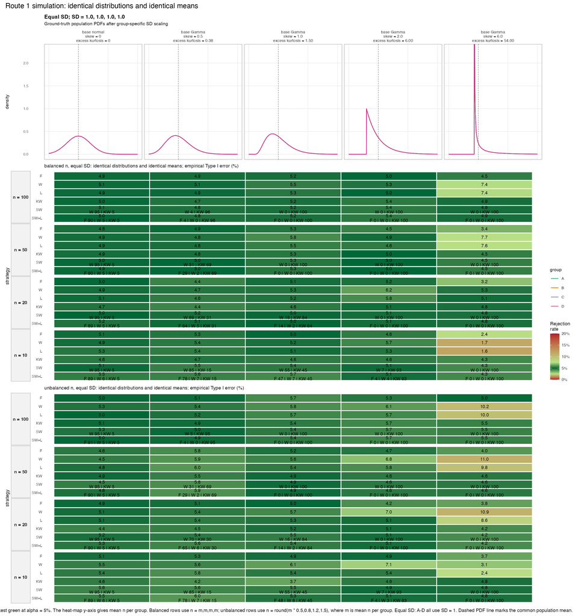

Route 1 simulation under identical distributions and identical means. The heatmap shows empirical rejection rates at alpha = 5%; green marks Bradley’s 2.5% to 7.5% range, and the upper panels show the corresponding population PDFs. Because distributions are identical, both equal-means and equal-rank-distribution null hypotheses are true.

| Strategy | $H_0$ tested | $H_0$ rejection | Outside Bradley bounds |
| --- | --- | --- | --- |
| F | equal means | 4.76% | 2.5% |
| W | equal means | 5.84% | 12.5% |
| L | equal means | 5.52% | 15.0% |
| KW | equal rank distributions | 4.82% | 0.0% |
| SW | selected final-test $H_0$ | 5.09% | 0.0% |
| SW+L | selected final-test $H_0$ | 5.14% | 0.0% |

In the unequal-distribution setting, the equal-means null remains true, but the Kruskal–Wallis null is false because group distributions differ in spread; hence standalone Kruskal–Wallis is not part of the mean-null Type I comparison. Welch has fewer Bradley-bound violations than Fisher and the Levene-gated route, so the Levene variance gate adds little as a Fisher/Welch decision rule. The full SW gate often routes to Kruskal–Wallis under skewness, which is defensible only if the automatic procedure is read as a visible switch from testing means to testing rank distributions (Figure @ref(fig:route1-unequal-mean-null-rejection)).

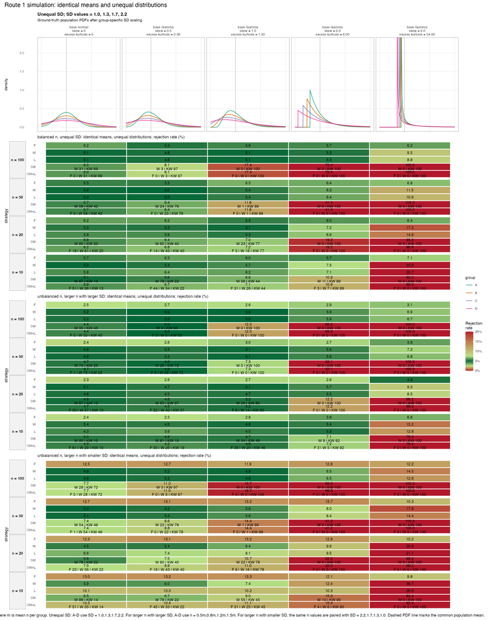

Route 1 simulation under identical means but unequal distributions. F, W, and L assess the equal-means null; SW and SW+L report rejection of the selected final-test null after routing. Standalone KW is omitted because equal rank distributions are not the ground-truth null in these rows.

| Strategy | $H_0$ tested | $H_0$ rejection | Outside Bradley bounds |
| --- | --- | --- | --- |
| Fisher | equal means | 7.17% | 40.0% |
| Welch | equal means | 7.93% | 21.7% |
| Levene F/W | equal means | 7.57% | 28.3% |
| SW gate | selected final-test $H_0$ | 30.55% | 63.3% |

## Power simulations

Power was estimated as the rejection probability under ordered location shifts of 0, 0.25, 0.50, and 0.75 SD across four balanced homoscedastic groups. In the normal and mildly skewed cases, the parametric routes have the highest power; in strongly skewed cases, Kruskal–Wallis becomes dominant. The SW+L route follows this switch and is equal or closest to the best-performing strategy across skewness levels. In the normal four-group corner, the small Fisher advantage over Welch follows directly from Eq. @ref(eq:welch-anova-four-groups), $\frac{F}{F_W}=1+3/[5(n-1)]$ (Figure @ref(fig:route1-power-skew-sweep)).

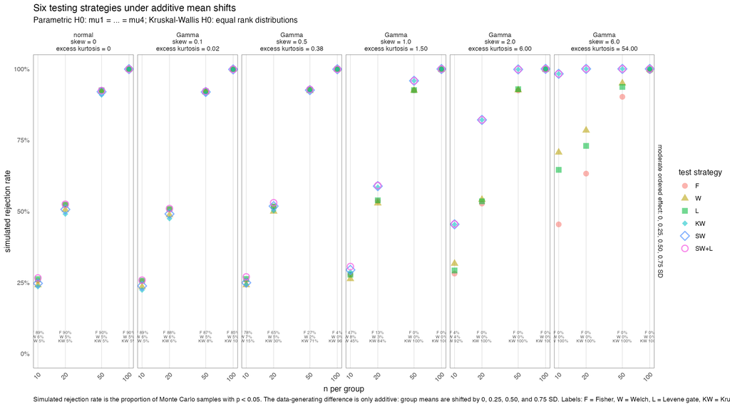

Power simulation under ordered additive group shifts of 0, 0.25, 0.50, and 0.75 SD. The y-axis shows the simulated rejection rate at alpha = 5% for six strategies across skewness and group size.

| skew | F | W | L | KW | SW | SW+L | best |
| --- | --- | --- | --- | --- | --- | --- | --- |
| 0.0 | 74.1% | 73.3% | 74.2% | 72.7% | 73.5% | 74.3% | SW+L |
| 0.1 | 73.6% | 72.8% | 73.7% | 72.2% | 72.9% | 73.8% | SW+L |
| 0.5 | 74.0% | 73.3% | 74.1% | 73.3% | 73.8% | 74.5% | SW+L |
| 1.0 | 74.8% | 74.3% | 74.8% | 76.6% | 76.8% | 77.1% | SW+L |
| 2.0 | 74.6% | 75.6% | 75.1% | 85.5% | 85.5% | 85.5% | SW+L |
| 6.0 | 79.6% | 88.8% | 86.2% | 99.7% | 99.7% | 99.7% | KW |

For the normal case (`skew = 0`), the small Fisher advantage over Welch can be checked directly against the algebraic factor from Eq. @ref(eq:welch-anova-four-groups), $\frac{F}{F_W}=1+3/[5(n-1)]$ (Figure @ref(fig:route1-parametric-power)).

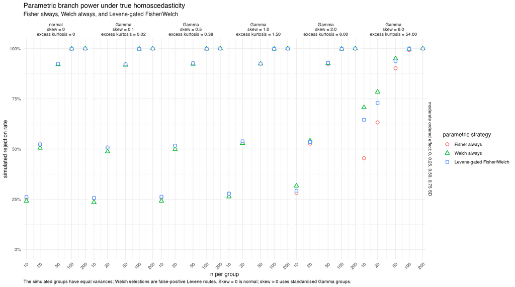

Parametric-branch power under true homoscedasticity. The plot compares Fisher always, Welch always, and the Levene-gated Fisher/Welch route.

| n | $F/F_W = 1 + 3/[5(n-1)]$ | F power | W power | F/W power |
| --- | --- | --- | --- | --- |
| 10 | 1.0667 | 25.7% | 24.1% | 1.06 |
| 20 | 1.0316 | 52.3% | 50.5% | 1.04 |
| 50 | 1.0122 | 92.5% | 92.1% | 1.00 |
| 100 | 1.0061 | 99.9% | 99.9% | 1.00 |
| 200 | 1.0030 | 100.0% | 100.0% | 1.00 |